# VOTO A VOX: PREELECTORAL OCTUBRE

### 2. Mapa: Tasas de desempleo en los jóvenes (20-24 años)

Ante la inminencia de una segunda crisis económica, ¿de qué situación parten los jóvenes en diferentes Comunidades Autónomas? Mapeo a nivel territorial la tasa de desempleo de jóvenes 20-24 años, donde se muestra patrones territoriales, así como las regiones donde las políticas para apoyar a este heterogéneo colectivo serán determinantes.

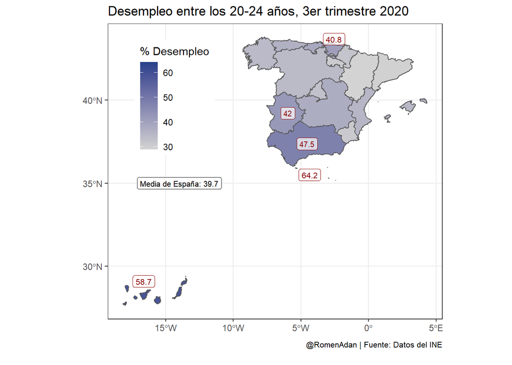

### 3. La confianza en el sistema legal

La confianza institucional se ha visto dañada en los últimos tiempos. En este gráfico, haciendo uso de la *European Social Survey*, se muestra la desconfianza de los ciudadanos españoles hacia su justicia.

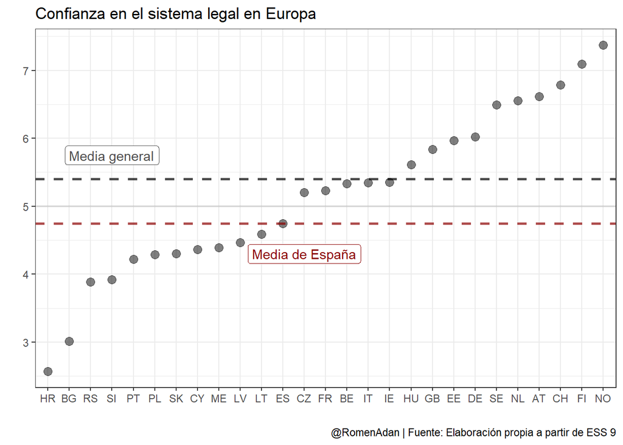

[output not shown]